# Introduction to R

30/09/2019

## Prerequisites

- Install necessary packages

```r
install.packages(c("devtools", "tidyverse", "knitr",
                   "lme4", "plotly", "BayesFactor", "rstanarm"))
devtools::install_github("easystats/easystats")
```

- Check if packages installed

```r
library(tidyverse)
library(easystats)
```

- Download the ‘emotion’ dataset in the `materials` folder at https://github.com/DominiqueMakowski/teaching

## Outline

1. Conceptual intro
2. Tools (R, Rstudio…)
3. Packages and data
4. Basic tests (correlations, *t*-tests, ANOVAs)
5. Regressions (GLMs)
6. Mixed Models
7. Taste of Bayes

## About me

- I am not a statistician
- I am not a programmer
- I am not a computer scientist
- I am not a geek *(originally…)*

## About you

- Programming?
- SPSS? MatLab? Python? …

## Why R?

- To catch up with the trend

[figure not shown]

## Why R?

- To catch up with the trend

[figure not shown]

## Why R?

### **R *vs.* SPSS, Excel, SAS…**

- Free
- Open-source
- Cross-platform
- Safe for your data
- Incredible community (twitter, stackoverflow, github…)
- Gold standart accross science
- Cutting-edge statistics and methods
- Reproducible research

## Why R?

### **R *vs.* Python**

- Python for signal processing, machine learning and other applications
- R for data manipulation, statistics, visualisation and communication ([1](https://neuropsychology.shinyapps.io/patientassessmentapp/), [2](https://malco.io/), [3](https://github.com/easystats/easystats/blob/master/publications/makowski_2019_bayesian/manuscript/preprint.pdf), [4](https://github.com/DominiqueMakowski/teaching/blob/master/R/2019_09_CBL_workshop/2019_09_CBL_workshop.Rmd))
- Use both!

## Long road ahead

- No course or workshop will teach you R
- Just dive in and try to accomplish a goal
- Steep learning curve
- Many frustrating moments
- People think “*now it’s not the best time for me to learn it, because I have to deliver X. I’ll do it when* `<insertSomething>`”
- Every minute invested in learning R will be worth it
- You won’t regret it!
- Biggest blockers: **fear and apprehension**

## Old R *vs.* new R

[figure not shown]

```r
# base R
data[data["col1"] < 3, c("col2", "col3" )]
```

[figure not shown]

```r
library(tidyverse)

data %>%
  filter(col1 < 3) %>%
  select(col2, col3)
```

## R and R studio

- Hands on!
- Editor and Console
- Theme
- Create an Rmarkdown file (`chunk output in console`)
- `R` chunks vs. `markdown` text
- Remove the first code chunk
- Try clicking on `Knit`
- Shortcuts
  - `CTLR + ENTER`: Run the selection
  - `CTRL + SHIFT + C`: Comment selection
  - `CTRL + SHIFT + M`: Ceci n’est pas une pipe `%>%`

## Install and Import Packages 📦

- Everything is done through **packages**
- Packages provide **new functions**
- The main challenge in R is not *“if something is possible”*, but rather *“what is the package that implements it the best”* (importance of staying “tuned”, r-bloggers, twitter, github…)
- Packages have to be *installed* only once, and *loaded* whenever you want to use their functions

```r
# Load the package
library(tidyverse)
```

## Discover functions and documentation

- **Don’t learn the functions!!!** Know what you want to do, and search for it (on google)

```r
anova()
```

- Show documentation (`F1` or `?function`)
- Google the CRAN repository page of the package ([`"bayestestR CRAN"`](https://www.google.com/search?q=bayestestR+CRAN&rlz=1C1CHBD_frSG849SG849&oq=bayestestR+CRAN&aqs=chrome..69i57j69i60l3j69i59.706j0j7&sourceid=chrome&ie=UTF-8))
- Check out the manual, the Github page or the *vignettes*

## Summary: Where to find help

- Google
- Stack Overflow
- Google
- Github (create issues)
- Stack Overflow
- Really, Stack Overflow

## Load data

- **Session -> Set Working Directory -> to Source File Location**
- A classic code line containg a *function* (e.g., `f()`), to which we provide inputs via *arguments* (e.g., `f(x)`) and that outputs something that be stored in an object (e.g., `y <- f(x)`)
- There are usually multiple arguments to function (e.g., `y <- f(x, great_workshop=TRUE, great_audience=TRUE)`)
- Assignments are traditionnaly done with `<-`, but `=` is equivalent

```r
df <- read.csv("materials/emotion.csv")
```

- Check the documentation of the function. Many other possible arguments with **default** values, that we can override.

```r
df <- read.csv("materials/emotion.csv", stringsAsFactors = FALSE)
```

## Explore the data

- Click on the object in the **Environment** panel to see it
- If the output of a function is not stored in an object, R will *print* it

```r
df
```

```
##     Participant_ID      Age    Sex Item_Category    Item_Name Trial_Order
## 1               1S 18.38467 Female        People People_158_h           1
## 2               1S 18.38467 Female         Faces  Faces_045_h           2
## 3               1S 18.38467 Female        People People_138_h           3
## 4               1S 18.38467 Female        People People_148_h           4
## 5               1S 18.38467 Female         Faces  Faces_315_h           5
## 6               1S 18.38467 Female         Faces  Faces_224_h           6
## 7               1S 18.38467 Female         Faces  Faces_016_h           7
## 8               1S 18.38467 Female         Faces  Faces_170_h           8
## 9               1S 18.38467 Female         Faces  Faces_362_v           9
## 10              1S 18.38467 Female         Faces  Faces_366_h          10
## 11              1S 18.38467 Female        People People_226_h          11
## 12              1S 18.38467 Female        People People_201_v          12
## 13              1S 18.38467 Female        People People_149_h          13
## 14              1S 18.38467 Female         Faces  Faces_057_h          14
```

[output cut: 1811 more lines]

## Explore the data

- Useful functions to describe objects, such as `summary()` or `report()` (in the easystats collection)

```r
library(easystats)
```

```r
report(df)
```

```
## The data contains 912 observations of the following variables:
##   - Participant_ID: 19 entries: 10S, n = 48; 11S, n = 48; 12S, n = 48 and 16 others
##   - Age: Mean = 21.08, SD = 2.11, range = [18.32, 26.43], 0 missing
##   - Sex: 2 entries: Female, n = 720; Male, n = 192
##   - Item_Category: 2 entries: Faces, n = 456; People, n = 456
##   - Item_Name: 48 entries: Faces_010_h, n = 19; Faces_016_h, n = 19; Faces_045_h, n = 19 and 45 others
##   - Trial_Order: Mean = 24.50, SD = 13.86, range = [1, 48], 0 missing
##   - Condition: 2 entries: Negative, n = 456; Neutral, n = 456
##   - Arousal: Mean = 45.94, SD = 30.13, range = [0, 100], 0 missing
##   - Valence: Mean = -18.90, SD = 51.57, range = [-100, 100], 0 missing
##   - SelfRelevance: Mean = 29.06, SD = 31.44, range = [0, 100], 0 missing
##   - Recall: 2 levels: FALSE (n = 600) and TRUE (n = 312)
```

## Explore the data

- Young and healthy adults watched pictures, that were either **Negative** or **Neutral** (the **`condition` variable**)
- For each picture (48 different items), they had to rate the **Intensity** (arousal) and **Valence** (positive - negative) of the emotion that they felt, as well as the **Self-Relevance** (the “autobiographical link”, i.e., how do they personally relate to the content of the picture)
- 30 min after the presentation, participants had to **recall** the images

## Explore the data

- Report the sample

```r
report_participants(df, age = "Age",
                    sex = "Sex",
                    participant = "Participant_ID")
```

```
## [1] "19 participants (Mean age = 21.08, SD = 2.17, range = [18.32, 26.43], 78.95% females)"
```

## Data Manipulation

- Summarize variables by condition
- The pipes (`%>%`) make the workflow easier to read (take this, do that, then that, …)

```r
df_condition <- df %>%
  group_by(Participant_ID, Condition) %>%
  summarise(Arousal = mean(Arousal),
            SelfRelevance = mean(SelfRelevance),
            Sex = unique(Sex))
```

## Data Manipulation

```r
head(df_condition)
```

```
## # A tibble: 6 x 5
## # Groups:   Participant_ID [3]
##   Participant_ID Condition Arousal SelfRelevance Sex
##   <chr>          <chr>       <dbl>         <dbl> <chr>
## 1 10S            Negative     82.6        49.9   Female
## 2 10S            Neutral      52.3        72.0   Female
## 3 11S            Negative     58.4         0.939 Female
## 4 11S            Neutral      12.2        23.6   Female
## 5 12S            Negative     69.3        30.2   Female
## 6 12S            Neutral      37.2        41.7   Female
```

## Data Manipulation

- From *long* format to *wide*

```r
df_sub <- df_condition %>%
  pivot_wider(names_from = "Condition",
              values_from = c("Arousal", "SelfRelevance"))
df_sub
```

```
## # A tibble: 19 x 6
## # Groups:   Participant_ID [19]
##    Participant_ID Sex   Arousal_Negative Arousal_Neutral SelfRelevance_N~
##    <chr>          <chr>            <dbl>           <dbl>            <dbl>
##  1 10S            Fema~             82.6           52.3            49.9
##  2 11S            Fema~             58.4           12.2             0.939
##  3 12S            Fema~             69.3           37.2            30.2
##  4 13S            Fema~             65.5           41.4            27.9
##  5 14S            Fema~             59.3           21.1             3.31
##  6 15S            Fema~             71.3           21.9            17.6
##  7 16S            Male              53.6            5.94           15.3
##  8 17S            Male              17.7            9.65            0.130
##  9 18S            Male              55.6           29.8            22.7
## 10 19S            Male              79.1           39.0            28.4
## 11 1S             Fema~             73.8            4.93            2.68
## 12 2S             Fema~             80.8           46.5            45.3
## 13 3S             Fema~             53.0           23.7            44.3
## 14 4S             Fema~             49.4           18.9            40.2
## 15 5S             Fema~             71.3           47.8            27.1
## 16 6S             Fema~             57.4           28.9            25.0
## 17 7S             Fema~             68.8           44.4             0.901
## 18 8S             Fema~             51.4           34.2            13.0
## 19 9S             Fema~             74.3           33.1            30.5
## # ... with 1 more variable: SelfRelevance_Neutral <dbl>
```

## Accessing things in objects

- Use the dollar `$` sign to access a specific variable of a dataframe

```r
df_sub$Arousal_Negative
```

```
##  [1] 82.60634 58.36689 69.32509 65.49479 59.30942 71.29991 53.60786
##  [8] 17.74631 55.58199 79.14497 73.79557 80.80512 53.03654 49.38151
## [15] 71.27821 57.35267 68.83681 51.43229 74.30301
```

```r
median(df_sub$Arousal_Negative)
```

```
## [1] 65.49479
```

```r
median(df_sub$Arousal_Neutral)
```

```
## [1] 29.78435
```

## *t*-tests

- *t*-tests can be performed using the `t.test` function

```r
t.test(df_sub$Arousal_Negative, df_sub$Arousal_Neutral)
```

```
##
##  Welch Two Sample t-test
##
## data:  df_sub$Arousal_Negative and df_sub$Arousal_Neutral
## t = 7.0005, df = 35.953, p-value = 3.301e-08
## alternative hypothesis: true difference in means is not equal to 0
## 95 percent confidence interval:
##  23.91953 43.43295
## sample estimates:
## mean of x mean of y
##  62.77396  29.09772
```

## *t*-tests

- The `report()` function can also be used in this case

```r
t.test(df_sub$Arousal_Negative, df_sub$Arousal_Neutral) %>%
  report()
```

```
## The Welch Two Sample t-test suggests that the difference between df_sub$Arousal_Negative and df_sub$Arousal_Neutral (mean of x = 62.77, mean of y = 29.10, difference = 33.68) is significant (t(35.95) = 7.00, 95% CI [23.92, 43.43], p < .001).
```

- About *pipes* (`%>%`):

```r
f(x, something=TRUE)
x %>% f(something=TRUE)
```

```r
result <- t.test(df_sub$Arousal_Negative, df_sub$Arousal_Neutral)
report(result)
```

```
## The Welch Two Sample t-test suggests that the difference between df_sub$Arousal_Negative and df_sub$Arousal_Neutral (mean of x = 62.77, mean of y = 29.10, difference = 33.68) is significant (t(35.95) = 7.00, 95% CI [23.92, 43.43], p < .001).
```

## Correlation

- Correlations can be done in a similar way

```r
cor.test(df_sub$SelfRelevance_Negative, df_sub$Arousal_Negative)
```

```
##
##  Pearson's product-moment correlation
##
## data:  df_sub$SelfRelevance_Negative and df_sub$Arousal_Negative
## t = 1.7902, df = 17, p-value = 0.09124
## alternative hypothesis: true correlation is not equal to 0
## 95 percent confidence interval:
##  -0.06829018  0.72189230
## sample estimates:
##       cor
## 0.3982727
```

## Bayesian correlation

- Need to load the `BayesFactor` package (case-sensitive!)

```r
library(BayesFactor)

correlationBF(df_sub$SelfRelevance_Negative, df_sub$Arousal_Negative) %>%
  model_parameters()
```

```
## Parameter | Median |         89% CI |     pd | % in ROPE |              Prior |   BF
## ------------------------------------------------------------------------------------
## rho       |   0.30 | [-0.02,  0.57] | 93.42% |     9.66% | Cauchy (0 +- 0.33) | 1.47
```

## Correlation Plot

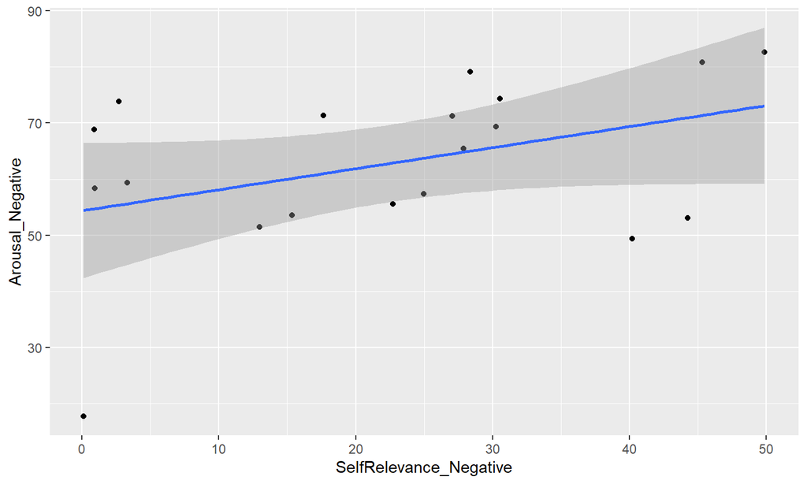

```r
p <- df_sub %>%
  ggplot(aes(x = SelfRelevance_Negative, y = Arousal_Negative)) +
  geom_point() +
  geom_smooth(method = "lm")
p
```

## Interactive plots

- Try this:

```r
library(plotly)
ggplotly(p)
```

## Conclusion

- Negative pictures elicit significantly more emotional **arousal**
- Anecdotal evidence for a positive correlation between the **self-relevance** and **arousal** for negative pictures
- New hypothesis: Could this be modulated by **Sex**?
- How? An ANOVA `Sex * self-relevance`?

## Create New Variables

```r
df_sub$SelfRelevance_Binary <- ifelse(
  df_sub$SelfRelevance_Negative > mean(df_sub$SelfRelevance_Negative),
  "High", "Low")
```

```r
report(df_sub$SelfRelevance_Binary)
```

```
## 2 entries: High, n = 11; Low, n = 8
```

## ANOVAs

- Done with the `aov()` function (Analysis Of Variance)
- The first argument is a formula `y ~ a + b`

```r
model <- aov(Arousal_Negative ~ Sex * SelfRelevance_Binary, data = df_sub)
```

## ANOVAs

```r
result <- report(model)
result
```

```
## The ANOVA suggests that:
##
##   - The main effect of Sex is not significant (F(1, 15) = 3.98, p = 0.06).
##   - The main effect of SelfRelevance_Binary is not significant (F(1, 15) = 2.53, p > .1).
##   - The interaction between Sex and SelfRelevance_Binary is not significant (F(1, 15) = 3.93, p = 0.07).
```

```r
to_table(result)
```

```
## Parameter                | Sum_Squares | df | Mean_Square |    F |    p
## -----------------------------------------------------------------------
## Sex                      |      641.67 |  1 |      641.67 | 3.98 | 0.06
## SelfRelevance_Binary     |      407.49 |  1 |      407.49 | 2.53 | > .1
## Sex:SelfRelevance_Binary |      633.97 |  1 |      633.97 | 3.93 | 0.07
## Residuals                |     2416.67 | 15 |      161.11 |      |
```

## Boxplots

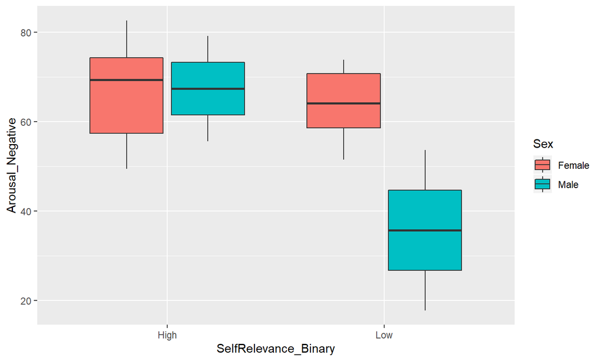

```r
df_sub %>%
  ggplot(aes(x = SelfRelevance_Binary, y = Arousal_Negative, fill = Sex)) +
  geom_boxplot()
```

## Boxplots (nicer)

- Reverse x-axis Order, tweak colors

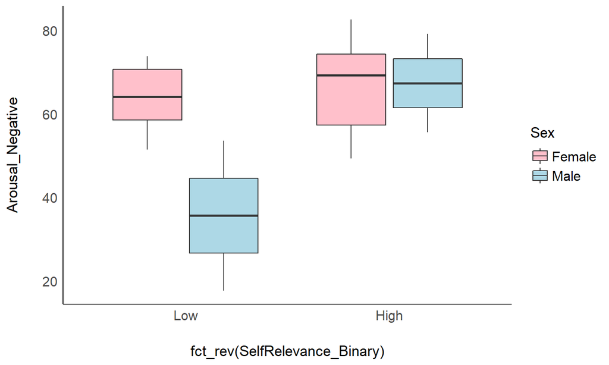

```r
df_sub %>%
  ggplot(aes(x = fct_rev(SelfRelevance_Binary), y = Arousal_Negative, fill = Sex)) +
  geom_boxplot() +
  theme_modern() +
  scale_fill_manual(values = c("pink", "lightblue"))
```

## Regressions

- Most of the “tests” taught *are* linear models (https://lindeloev.github.io/tests-as-linear/)
- Much more informative and powerful

```r
model <- aov(Arousal_Negative ~ Sex * SelfRelevance_Binary, data = df_sub)
```

```r
model <- lm(Arousal_Negative ~ Sex * SelfRelevance_Binary, data = df_sub)
anova(model)
```

```
## Analysis of Variance Table
##
## Response: Arousal_Negative
##                          Df  Sum Sq Mean Sq F value  Pr(>F)
## Sex                       1  641.67  641.67  3.9828 0.06446 .
## SelfRelevance_Binary      1  407.49  407.49  2.5293 0.13260
## Sex:SelfRelevance_Binary  1  633.97  633.97  3.9350 0.06590 .
## Residuals                15 2416.67  161.11
## ---
## Signif. codes:  0 '***' 0.001 '**' 0.01 '*' 0.05 '.' 0.1 ' ' 1
```

## Regressions

```r
result <- report(model)
result
```

```
## We fitted a linear model to predict Arousal_Negative with Sex and SelfRelevance_Binary.The model's explanatory power is substantial (R2 = 0.41, adj. R2 = 0.29). The model's intercept is at 67.06. Whithin this model:
##
##   - The effect of Sex (Male) is positive and can be considered as tiny and not significant (beta = 0.30, 95% CI [-20.85, 21.45], std. beta = 0.02, p > .1).
##   - The effect of SelfRelevance_Binary (Low) is negative and can be considered as small and not significant (beta = -3.22, 95% CI [-17.48, 11.03], std. beta = -0.21, p > .1).
##   - The interaction effect of SelfRelevance_Binary (Low) on Sex (Male) is negative and can be considered as very large and not significant (beta = -28.46, 95% CI [-59.04, 2.12], std. beta = -1.89, p = 0.07).
```

```r
to_table(result)
```

```
## Parameter                       | Coefficient |             95% CI |      p | Coefficient (std.) |  Fit
## -------------------------------------------------------------------------------------------------------
## (Intercept)                     |       67.06 | [  58.05,   76.08] | < .001 |               0.28 |
## SexMale                         |        0.30 | [ -20.85,   21.45] | > .1   |               0.02 |
## SelfRelevance_BinaryLow         |       -3.22 | [ -17.48,   11.03] | > .1   |              -0.21 |
## SexMale:SelfRelevance_BinaryLow |      -28.46 | [ -59.04,    2.12] | 0.07   |              -1.89 |
##                                 |             |                    |        |                    |
## R2                              |             |                    |        |                    | 0.41
## R2 (adj.)                       |             |                    |        |                    | 0.29
```

## Regressions

- Can mix continuous and categorical variables

```r
model <- lm(Arousal_Negative ~ Sex * SelfRelevance_Negative, data = df_sub)

model %>%
  report() %>%
  to_table()
```

```
## Parameter                      | Coefficient |             95% CI |      p | Coefficient (std.) |  Fit
## ------------------------------------------------------------------------------------------------------
## (Intercept)                    |       62.77 | [  52.78,   72.76] | < .001 |               0.19 |
## SexMale                        |      -44.75 | [ -67.41,  -22.09] | < .001 |              -0.16 |
## SelfRelevance_Negative         |        0.13 | [  -0.22,    0.47] | > .1   |               0.13 |
## SexMale:SelfRelevance_Negative |        1.89 | [   0.80,    2.97] | < .01  |               2.01 |
##                                |             |                    |        |                    |
## R2                             |             |                    |        |                    | 0.62
## R2 (adj.)                      |             |                    |        |                    | 0.54
```

## Model Visualisation (Optional)

- A model can best be understood when visualised

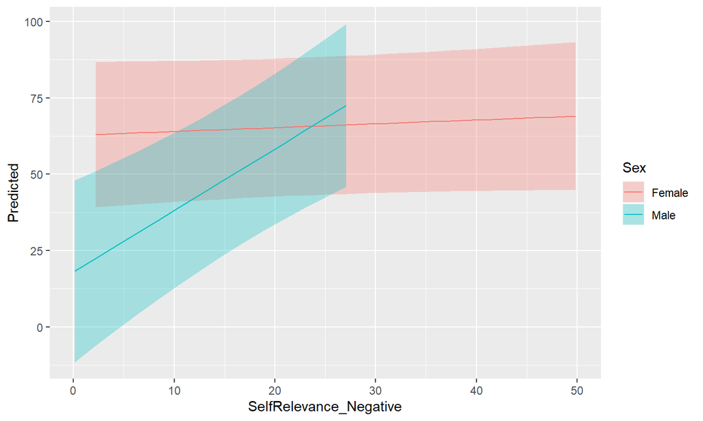

```r
model %>%
  estimate_link() %>%
  ggplot(aes(y = Predicted, x = SelfRelevance_Negative)) +
  geom_ribbon(aes(ymin=CI_low, ymax=CI_high, fill=Sex), alpha = 0.3) +
  geom_line(aes(color = Sex))
```

```r
  ylab("Predicted Arousal")
```

```
## $y
## [1] "Predicted Arousal"
##
## attr(,"class")
## [1] "labels"
```

## Model Visualisation (with points)

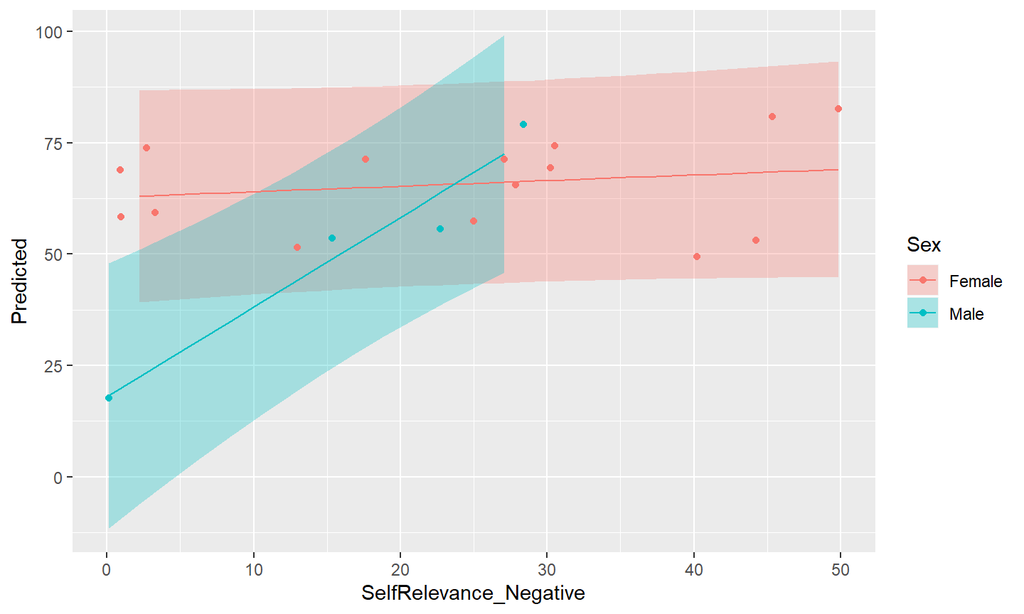

```r
model %>%
  estimate_link() %>%
  ggplot(aes(y = Predicted, x = SelfRelevance_Negative)) +
  geom_ribbon(aes(ymin=CI_low, ymax=CI_high, fill=Sex), alpha = 0.3) +
  geom_line(aes(color = Sex)) +
  geom_point(data = df_sub, aes(y = Arousal_Negative, color = Sex))
```

## Adding the Condition

- Let’s drop the sex but investigate the whole set of pictures (including neutral)
- Is there a relationship between self-relevance and arousal for the neutral pictures?

```r
lm(Arousal ~ Condition * SelfRelevance, data = df_condition) %>%
  report() %>%
  to_table()
```

```
## Parameter                      | Coefficient |             95% CI |      p | Coefficient (std.) |  Fit
## ------------------------------------------------------------------------------------------------------
## (Intercept)                    |       54.38 | [  44.16,   64.61] | < .001 |               0.86 |
## ConditionNeutral               |      -44.21 | [ -60.34,  -28.09] | < .001 |              -1.77 |
## SelfRelevance                  |        0.37 | [   0.00,    0.75] | < .05  |               0.31 |
## ConditionNeutral:SelfRelevance |        0.16 | [  -0.33,    0.64] | > .1   |               0.13 |
##                                |             |                    |        |                    |
## R2                             |             |                    |        |                    | 0.71
## R2 (adj.)                      |             |                    |        |                    | 0.69
```

## Mixed Models

- There is a hierarchical (i.e., grouped) structure

```r
library(lme4)

model <- lmer(Arousal ~ Condition * SelfRelevance + (1|Participant_ID),
              data = df_condition)

model %>%
  report() %>%
  to_table()
```

```
## Parameter                      | Coefficient |             95% CI |      p | Coefficient (std.) |  Fit
## ------------------------------------------------------------------------------------------------------
## (Intercept)                    |       54.63 | [  44.94,   64.32] | < .001 |               0.86 |
## ConditionNeutral               |      -42.55 | [ -55.26,  -29.84] | < .001 |              -1.75 |
## SelfRelevance                  |        0.36 | [   0.01,    0.72] | < .05  |               0.31 |
## ConditionNeutral:SelfRelevance |        0.11 | [  -0.27,    0.50] | > .1   |               0.09 |
##                                |             |                    |        |                    |
## R2_conditional                 |             |                    |        |                    | 0.80
## R2_marginal                    |             |                    |        |                    | 0.69
```

## Predicting the Recall of Items

- Investigate the determinants of item recall

```r
report(df)
```

```
## The data contains 912 observations of the following variables:
##   - Participant_ID: 19 entries: 10S, n = 48; 11S, n = 48; 12S, n = 48 and 16 others
##   - Age: Mean = 21.08, SD = 2.11, range = [18.32, 26.43], 0 missing
##   - Sex: 2 entries: Female, n = 720; Male, n = 192
##   - Item_Category: 2 entries: Faces, n = 456; People, n = 456
##   - Item_Name: 48 entries: Faces_010_h, n = 19; Faces_016_h, n = 19; Faces_045_h, n = 19 and 45 others
##   - Trial_Order: Mean = 24.50, SD = 13.86, range = [1, 48], 0 missing
##   - Condition: 2 entries: Negative, n = 456; Neutral, n = 456
##   - Arousal: Mean = 45.94, SD = 30.13, range = [0, 100], 0 missing
##   - Valence: Mean = -18.90, SD = 51.57, range = [-100, 100], 0 missing
##   - SelfRelevance: Mean = 29.06, SD = 31.44, range = [0, 100], 0 missing
##   - Recall: 2 levels: FALSE (n = 600) and TRUE (n = 312)
```

## A Logistic Mixed Model

- Investigate the determinants of item recall

```r
model <- glmer(Recall ~ Condition * SelfRelevance +
                 (1|Participant_ID) + (1|Item_Name),
               family = "binomial", data = df)
report(model) %>%
  to_table()
```

```
## Can't calculate log-loss.
```

```
## Parameter                      | Coefficient |             95% CI |     p | Coefficient (std.) |  Fit
## -----------------------------------------------------------------------------------------------------
## (Intercept)                    |       -0.54 | [  -0.91,   -0.17] | < .01 |              -0.45 |
## ConditionNeutral               |       -0.83 | [  -1.36,   -0.31] | < .01 |              -0.62 |
## SelfRelevance                  |        0.00 | [  -0.00,    0.01] | > .1  |               0.10 |
## ConditionNeutral:SelfRelevance |        0.01 | [  -0.00,    0.02] | > .1  |               0.23 |
##                                |             |                    |       |                    |
## R2_conditional                 |             |                    |       |                    | 0.14
## R2_marginal                    |             |                    |       |                    | 0.04
```

## A Bayesian Logistic Mixed Model

```r
library(rstanarm)

model <- stan_glmer(Recall ~ Condition * SelfRelevance +
                      (1|Participant_ID) + (1|Item_Name),
                    family = "binomial", data = df)
```

## A Bayesian Logistic Mixed Model

```r
library(rstanarm)

model <- stan_glmer(Recall ~ Condition * SelfRelevance +
                      (1|Participant_ID) + (1|Item_Name),
                    family = "binomial", data = df, iter = 500)
```

## A Bayesian Logistic Mixed Model

```r
report(model) %>%
  to_table()
```

```
## Can't calculate log-loss.
```

```
## Parameter                      | Median |             89% CI |     pd | % in ROPE | Median (std.) |  Fit
## --------------------------------------------------------------------------------------------------------
## (Intercept)                    |  -0.56 | [  -0.89,   -0.24] | 99.70% |     2.70% |          0.00 |
## ConditionNeutral               |  -0.84 | [  -1.31,   -0.42] | 99.90% |     0.70% |         -0.84 |
## SelfRelevance                  |   0.00 | [  -0.00,    0.01] | 81.90% |      100% |          0.10 |
## ConditionNeutral:SelfRelevance |   0.01 | [  -0.00,    0.01] | 93.90% |      100% |          0.23 |
##                                |        |                    |        |           |               |
## R2                             |        |                    |        |           |               | 0.11
## R2_marginal                    |        |                    |        |           |               | 0.03
```

## Visualisation

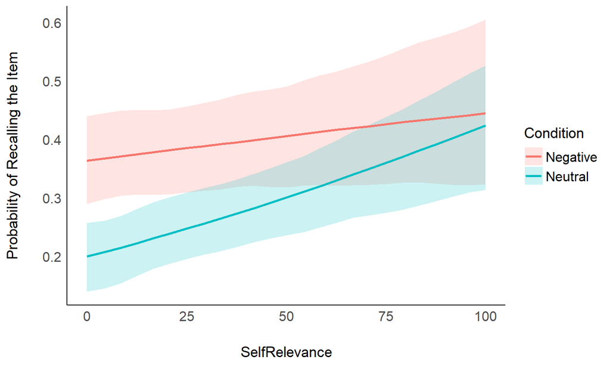

```r
model %>%
  estimate_link() %>%
  ggplot(aes(x = SelfRelevance, y = Median)) +
  geom_ribbon(aes(ymin = CI_low, ymax = CI_high, fill = Condition), alpha = 0.2) +
  geom_line(aes(color = Condition), size = 1)  +
  theme_modern() +
  ylab("Probability of Recalling the Item")
```

## Resources

- https://easystats.github.io/blog/resources/
- Bayesian tutorial: https://easystats.github.io/bayestestR/
- Structural modelling: https://easystats.github.io/parameters/articles/efa_cfa.html
- **Thank you!**

`dom.makowski@gmail.com`